# 5. Water-year and seasonal area weighted precipitation and error estimates

## Water year precipitation

Alternatively the water-year area weighted total precipitation cn be extracted. To do this, an index to start of each water year is required. Here the water year starts on the first of March. Note, the same approach can be used to extract data over other time steps, such as seasonal.

```r
dates = seq.Date(date.from, date.to, by ='day')
wateryear.ind = which(as.numeric(format(dates, '%m')) == 3 & as.numeric(format(dates, '%d'))==1)
```

```r
climateData.daily2wateryear = extract_data(ncdfFilename = ncdfFilename,
                      extractFrom = date.from,
                      extractTo = date.to,
                      vars = c('precip'),
                      locations = catch,
                      temporal.timestep = wateryear.ind,
                      temporal.fn.inner = 'sum',
                      spatial.fn = 'var')
```

```
#> Extraction data summary:
#>     NetCDF climate data exists from 2010-01-01 to 2015-12-31
#>     Data will be extracted from  2010-01-01  to  2015-12-31  at  2  locations
#> Setting up data extraction:
#> ... Testing aggregation functions:
#>    ... Testing temporal aggregation
#>    ... Testing spatial aggregation
#> ... Building location weights for each grid.
#> Starting data extraction across all variable and locations:
#> ... Infilling data gaps by interpolating over time, then back-filling.
#>    ... Linearly interpolating gaps.
#>    ... Backfilling dates prior to the start of observations (if required).
#>     Summary of NAs initially, and after each step.
#>        pre.filled post.time.interpolated post.backfilling
#> precip          0                      0                0
#> ... Calculating area weighted results at required time-step.
#> Data extraction FINISHED.
#> Total run time (DD:HH:MM:SS): 00:00:00:01
```

Now let’s estimate the uncertainty in the water year rainfall using the root mean square interpolation error (RMSE).

```r
climateData.daily2wateryear.err = extract_data(ncdfFilename = ncdfFilename,
                      extractFrom = date.from,
                      extractTo = date.to,
                      vars = c('precip.RMSE'),
                      locations = catch,
                      temporal.timestep = wateryear.ind,
                      temporal.fn.inner = sqrd_sum,
                      spatial.fn = 'var')
```

```
#> Extraction data summary:
#>     NetCDF climate data exists from 2010-01-01 to 2015-12-31
#>     Data will be extracted from  2010-01-01  to  2015-12-31  at  2  locations
#> Setting up data extraction:
#> ... Testing aggregation functions:
#>    ... Testing temporal aggregation
#>    ... Testing spatial aggregation
#> ... Building location weights for each grid.
#> Starting data extraction across all variable and locations:
#> ... Infilling data gaps by interpolating over time, then back-filling.
#>    ... Linearly interpolating gaps.
#>    ... Backfilling dates prior to the start of observations (if required).
#>     Summary of NAs initially, and after each step.
#>             pre.filled post.time.interpolated post.backfilling
#> precip.RMSE          0                      0                0
#> ... Calculating area weighted results at required time-step.
#> Data extraction FINISHED.
#> Total run time (DD:HH:MM:SS): 00:00:00:01
```

Finally, let’s also extract the water year using the monthly gridded precipitation data.

```r
dates = seq.Date(date.from, date.to, by ='month')
wateryear.ind = which(as.numeric(format(dates, '%m')) == 3 & as.numeric(format(dates, '%d'))==1)
```

```r
climateData.month2wateryear = extract_data(ncdfFilename = ncdfFilename,
                      extractFrom = date.from,
                      extractTo = date.to,
                      vars = c('precip.monthly'),
                      locations = catch,
                      temporal.timestep = wateryear.ind,
                      temporal.fn.inner = 'sum',
                      spatial.fn = 'var')
```

```
#> Extraction data summary:
#>     NetCDF climate data exists from 2010-01-01 to 2015-12-31
#>     Data will be extracted from  2010-01-01  to  2015-12-31  at  2  locations
#> Setting up data extraction:
#> ... Testing aggregation functions:
#>    ... Testing temporal aggregation
#>    ... Testing spatial aggregation
#> ... Building location weights for each grid.
#> Starting data extraction across all variable and locations:
#> ... Infilling data gaps by interpolating over time, then back-filling.
#>    ... Linearly interpolating gaps.
#>    ... Backfilling dates prior to the start of observations (if required).
#>     Summary of NAs initially, and after each step.
#>                pre.filled post.time.interpolated post.backfilling
#> precip.monthly         53                      0                0
#> ... Calculating area weighted results at required time-step.
#> Data extraction FINISHED.
#> Total run time (DD:HH:MM:SS): 00:00:00:01
```

Before plotting the water year data, the time steps with less than a full water year of data are filtered out.

```r
filt = climateData.daily2wateryear$temporal$days.per.timestep >= 365
climateData.daily2wateryear$temporal = climateData.daily2wateryear$temporal[filt, ]

filt = climateData.daily2wateryear.err$temporal$days.per.timestep >= 365
climateData.daily2wateryear.err$temporal = climateData.daily2wateryear.err$temporal[filt, ]

filt = climateData.month2wateryear$temporal$months.per.timestep == 12
climateData.month2wateryear$temporal = climateData.month2wateryear$temporal[filt, ]
```

Now let’s compare the two estimates of water year precipitation at the two catchments. The blue line shows the water year total rainfall calculated from the daily data, with the black vertical bars denoting the estimated 5th to 95th error from the interpolation of rain gauges. The red line shows the the water year total rainfall calculated from the monthly data.

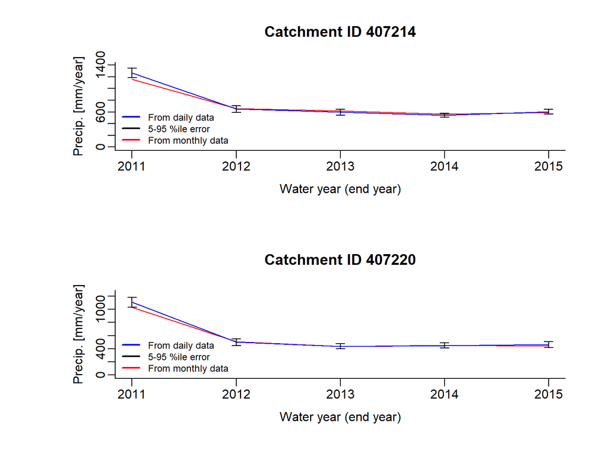

```r
par(mfrow=c(2,1), mar =  c(5, 7.5, 4, 2.7) + 0.1)

# Loop through each catchment and plot.
for (i in 1:length(site_ID)) {

  # Water years precipitation from monthly data.
  filt = climateData.month2wateryear$temporal$Location.ID == site_ID[i]
  tmp.date = climateData.month2wateryear$temporal[filt,]
  x.data = tmp.date$year
  y.data = tmp.date$precip.monthly

  plot(x = x.data,
       y = y.data,
       type = "l",
       col = "red",
       lwd = 1.2,
       mgp = c(2, 0.5, 0),
       ylim = c(0, ceiling(max(y.data) * 1.2)),
       ylab = "Precip. [mm/year]",
       xlab = "Water year (end year)",
       xaxs = "r",
       bty = "l",
       yaxs = "r",
       main=paste('Catchment ID',site_ID[i]))

  # Get water year data from daily data.
  filt = climateData.daily2wateryear$temporal$Location.ID == site_ID[i]
  tmp.date = climateData.daily2wateryear$temporal[filt,]
  x.data = tmp.date$year
  y.data = tmp.date$precip
  tmp.date = climateData.daily2wateryear.err$temporal[filt,]
  y.data.low = y.data - 1.645 * sqrt(tmp.date$precip.RMSE)
  y.data.hi = y.data + 1.645 * sqrt(tmp.date$precip.RMSE)

  lines(x = x.data,
       y = y.data,
       type = "l",
       col = "blue",
       lwd = 1.2)

  # Add interpolation error bars for water years precipitation from daily data
  arrows(x0 = x.data,
         y0 = y.data.low,
         x1 = x.data,
         y1 = y.data.hi,
         angle=90,
         code=3,
         length=0.06,
         col="black")

  # Add legend
  legend("bottomleft",
         lwd = 2,
         bty = "n",
         inset = c(0.01, -0.01),
         lty = c(1, 1, 1), pch = c(NA, NA, NA),
         col = c("blue",  "black", "red"),
         legend = c("From daily data", "5-95 %ile error", "From monthly data"),
         xpd = NA,
         cex=0.75)
}
```

## Seasonal rainfall climatology

```r
clim.seasonal = extract_data(ncdfFilename = ncdfFilename,
                      extractFrom = date.from,
                      extractTo = date.to,
                      vars = c('precip', 'precip.monthly'),
                      locations = catch,
                      temporal.timestep = 'seasonal',
                      temporal.fn.outer = 'clim',
                      temporal.fn.inner = 'sum',
                      spatial.fn = 'var')
```

```
#> Extraction data summary:
#>     NetCDF climate data exists from 2010-01-01 to 2015-12-31
#>     Data will be extracted from  2010-01-01  to  2015-12-31  at  2  locations
#> Setting up data extraction:
#> ... Testing aggregation functions:
#>    ... Testing temporal aggregation
#>    ... Testing spatial aggregation
#> ... Building location weights for each grid.
#> Starting data extraction across all variable and locations:
#> ... Infilling data gaps by interpolating over time, then back-filling.
#>    ... Linearly interpolating gaps.
#>    ... Backfilling dates prior to the start of observations (if required).
#>     Summary of NAs initially, and after each step.
#>                pre.filled post.time.interpolated post.backfilling
#> precip                  0                      0                0
#> precip.monthly         53                      0                0
#> ... Calculating area weighted results at required time-step.
#> Data extraction FINISHED.
#> Total run time (DD:HH:MM:SS): 00:00:00:01
```

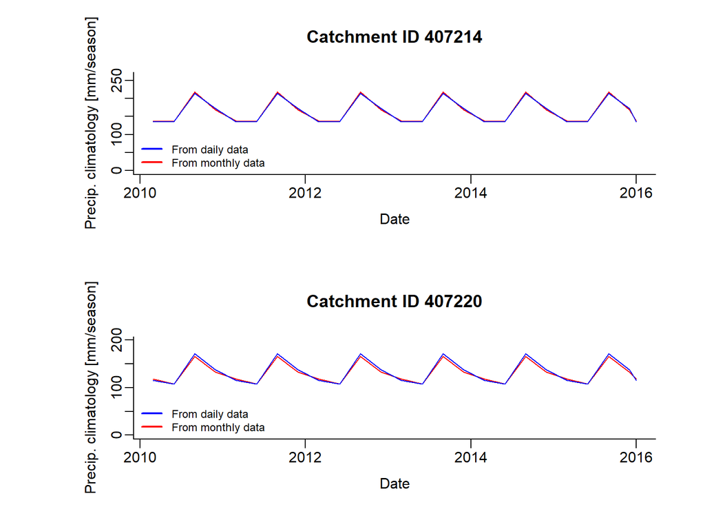

```r
par(mfrow=c(length(site_ID), 1),
    mar =  c(5, 7.5, 4, 2.7) + 0.1)

# Loop through each catchment and plot.
for (i in 1:length(site_ID)) {

  # Water years precipitation from monthly data.
  filt = clim.seasonal$temporal$Location.ID == site_ID[i]
  tmp.date = clim.seasonal$temporal[filt,]
  x.data = as.Date(paste0(tmp.date$year,'-',
                          tmp.date$month,'-',
                          tmp.date$day))
  y.data = tmp.date$precip.monthly

  plot(x = x.data,
       y = y.data,
       type = "l",
       col = "red",
       lwd = 1.2,
       mgp = c(2, 0.5, 0),
       ylim = c(0, ceiling(max(y.data) * 1.2)),
       ylab = "Precip. climatology [mm/season]",
       xlab = "Date",
       xaxs = "r",
       bty = "l",
       yaxs = "r",
       main=paste('Catchment ID',site_ID[i]))

  y.data = tmp.date$precip
  lines(x = x.data,
       y = y.data,
       type = "l",
       col = "blue",
       lwd = 1.2)

  # Add legend
  legend("bottomleft",
         lwd = 2,
         bty = "n",
         inset = c(0.01, -0.01),
         lty = c(1, 1), pch = c(NA, NA),
         col = c("blue", "red"),
         legend = c("From daily data", "From monthly data"),
         xpd = NA,
         cex=0.75)
}
```

## Seasonal cumulative rainfall anomaly

```r
annom.seasonal = extract_data(ncdfFilename = ncdfFilename,
                      extractFrom = date.from,
                      extractTo = date.to,
                      vars = c('precip', 'precip.monthly'),
                      locations = catch,
                      temporal.timestep = 'seasonal',
                      temporal.fn.outer = 'annom',
                      temporal.fn.inner = 'sum',
                      spatial.fn = 'var')
```

```
#> Extraction data summary:
#>     NetCDF climate data exists from 2010-01-01 to 2015-12-31
#>     Data will be extracted from  2010-01-01  to  2015-12-31  at  2  locations
#> Setting up data extraction:
#> ... Testing aggregation functions:
#>    ... Testing temporal aggregation
#>    ... Testing spatial aggregation
#> ... Building location weights for each grid.
#> Starting data extraction across all variable and locations:
#> ... Infilling data gaps by interpolating over time, then back-filling.
#>    ... Linearly interpolating gaps.
#>    ... Backfilling dates prior to the start of observations (if required).
#>     Summary of NAs initially, and after each step.
#>                pre.filled post.time.interpolated post.backfilling
#> precip                  0                      0                0
#> precip.monthly         53                      0                0
#> ... Calculating area weighted results at required time-step.
#> Data extraction FINISHED.
#> Total run time (DD:HH:MM:SS): 00:00:00:01
```

Now let’s also calculate the the area weighted seasonal cumulative rainfall anomaly. Note, like the anomaly calculation, many other functions are available for the within-seasonal calculation.

```r
cumannom.seasonal = extract_data(ncdfFilename = ncdfFilename,
                      extractFrom = date.from,
                      extractTo = date.to,
                      vars = c('precip', 'precip.monthly'),
                      locations = catch,
                      temporal.timestep = 'seasonal',
                      temporal.fn.outer = 'cumannom',
                      temporal.fn.inner = 'sum',
                      spatial.fn = 'var')
```

```
#> Extraction data summary:
#>     NetCDF climate data exists from 2010-01-01 to 2015-12-31
#>     Data will be extracted from  2010-01-01  to  2015-12-31  at  2  locations
#> Setting up data extraction:
#> ... Testing aggregation functions:
#>    ... Testing temporal aggregation
#>    ... Testing spatial aggregation
#> ... Building location weights for each grid.
#> Starting data extraction across all variable and locations:
#> ... Infilling data gaps by interpolating over time, then back-filling.
#>    ... Linearly interpolating gaps.
#>    ... Backfilling dates prior to the start of observations (if required).
#>     Summary of NAs initially, and after each step.
#>                pre.filled post.time.interpolated post.backfilling
#> precip                  0                      0                0
#> precip.monthly         53                      0                0
#> ... Calculating area weighted results at required time-step.
#> Data extraction FINISHED.
#> Total run time (DD:HH:MM:SS): 00:00:00:01
```

Now let’s compare the two estimates the precipitation anomaly and cumulative anomaly at the two catchments. The blue line shows that calculated from the daily data and the red line shows that calculated from the monthly data.

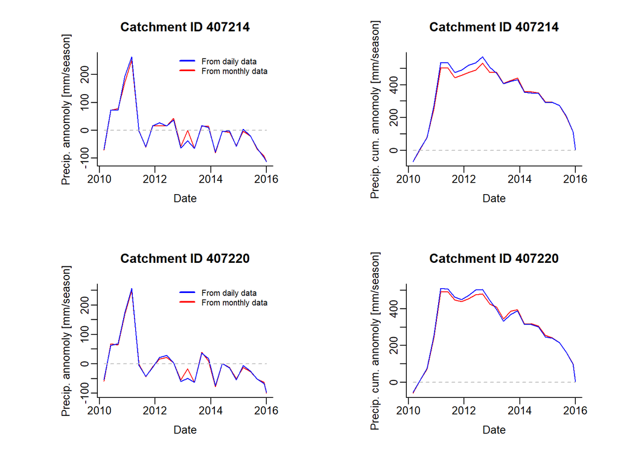

```r
par(mfrow=c(2,2), mar =  c(5, 7.5, 4, 2.7) + 0.1)

# Loop through each catchment and plot.
for (i in 1:length(site_ID)) {

  # Water years precipitation from monthly data.
  filt = annom.seasonal$temporal$Location.ID == site_ID[i]
  tmp.date = annom.seasonal$temporal[filt,]
  x.data = as.Date(paste0(tmp.date$year,'-',
                          tmp.date$month,'-',
                          tmp.date$day))
  y.data = tmp.date$precip.monthly

  shared_limits <- range(c(y.data, tmp.date$precip))

  plot(x = x.data,
       y = y.data,
       type = "l",
       col = "red",
       lwd = 1.2,
       mgp = c(2, 0.5, 0),
       ylim = shared_limits,
       ylab = "Precip. annomoly [mm/season]",
       xlab = "Date",
       xaxs = "r",
       bty = "l",
       yaxs = "r",
       main=paste('Catchment ID',site_ID[i]))

  y.data = tmp.date$precip
  lines(x = x.data,
       y = y.data,
       type = "l",
       col = "blue",
       lwd = 1.2)

  lines(range(x.data), c(0, 0), col='grey', lty = "dashed")

    # Add legend
  legend("topright",
         lwd = 2,
         bty = "n",
         inset = c(0.01, -0.01),
         lty = c(1, 1), pch = c(NA, NA),
         col = c("blue", "red"),
         legend = c("From daily data", "From monthly data"),
         xpd = NA,
         cex=0.75)

  tmp.date = cumannom.seasonal$temporal[filt,]
  y.data = tmp.date$precip.monthly
  shared_limits <- range(c(y.data, tmp.date$precip))
  plot(x = x.data,
       y = y.data,
       type = "l",
       col = "red",
       lwd = 1.2,
       mgp = c(2, 0.5, 0),
       ylim = shared_limits,
       ylab = "Precip. cum. annomoly [mm/season]",
       xlab = "Date",
       xaxs = "r",
       bty = "l",
       yaxs = "r",
       main=paste('Catchment ID', site_ID[i]))

  y.data = tmp.date$precip
  lines(x = x.data,
       y = y.data,
       type = "l",
       col = "blue",
       lwd = 1.2)

  lines(range(x.data), c(0, 0), col='grey', lty = "dashed")
}
```

Custom functions can also be used to aggregate the extracted data to the required time-step. To illustrate, the function below calculates the mean precipitation event (>=1mm/day) duration.

```r
runlength_precip <- function(x) {
  # Precip events >1 mm/day
  ind <- as.vector(x >=1)

  # Do run length analysis
  r <- rle(ind)

  # Return median event run length
  return(mean(r$lengths))
}
```

The custom function can then be used in the data extraction function. Here is is used to calculate the water-year mean precipitation event duration, but any other time step (e.g. seasonal) could be used.

```r
dates = seq.Date(date.from, date.to, by ='day')
wateryear.ind = which(as.numeric(format(dates, '%m')) == 3 & as.numeric(format(dates, '%d'))==1)

rle.wateryear <- extract_data(ncdfFilename = ncdfFilename,
             extractFrom = date.from,
             extractTo = date.to,
             vars = c('precip'),
             locations = catch,
             temporal.timestep = wateryear.ind,
             temporal.fn.outer = NA,
             temporal.fn.inner = runlength_precip,
             spatial.fn = 'var')
```

```
#> Extraction data summary:
#>     NetCDF climate data exists from 2010-01-01 to 2015-12-31
#>     Data will be extracted from  2010-01-01  to  2015-12-31  at  2  locations
#> Setting up data extraction:
#> ... Testing aggregation functions:
#>    ... Testing temporal aggregation
#>    ... Testing spatial aggregation
#> ... Building location weights for each grid.
#> Starting data extraction across all variable and locations:
#> ... Infilling data gaps by interpolating over time, then back-filling.
#>    ... Linearly interpolating gaps.
#>    ... Backfilling dates prior to the start of observations (if required).
#>     Summary of NAs initially, and after each step.
#>        pre.filled post.time.interpolated post.backfilling
#> precip          0                      0                0
#> ... Calculating area weighted results at required time-step.
#> Data extraction FINISHED.
#> Total run time (DD:HH:MM:SS): 00:00:00:01
```

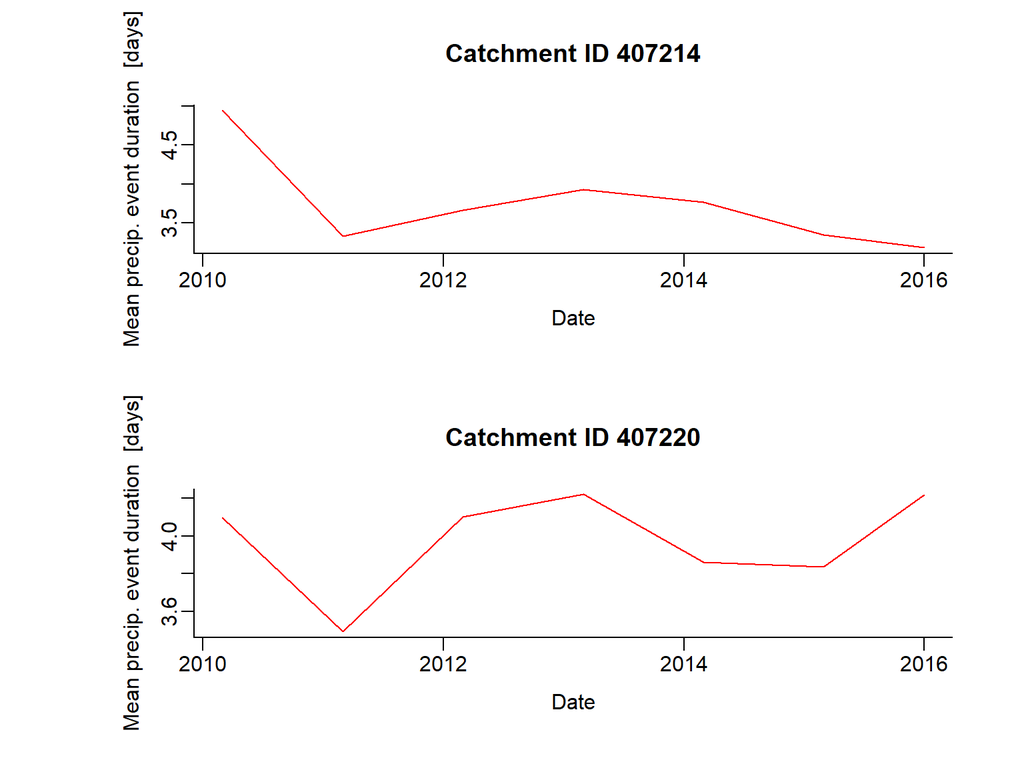

```r
par(mfrow=c(length(site_ID), 1),
    mar =  c(5, 7.5, 4, 2.7) + 0.1)

# Loop through each catchment and plot.
for (i in 1:length(site_ID)) {
  filt = rle.wateryear$temporal$Location.ID == site_ID[i]
  tmp.date = rle.wateryear$temporal[filt,]
  x.data = as.Date(paste0(tmp.date$year,'-',
                          tmp.date$month,'-',
                          tmp.date$day))
  y.data = tmp.date$precip

  plot(x = x.data,
       y = y.data,
       type = "l",
       col = "red",
       lwd = 1.2,
       mgp = c(2, 0.5, 0),
       ylab = "Mean precip. event duration  [days]",
       xlab = "Date",
       xaxs = "r",
       bty = "l",
       yaxs = "r",
       main=paste('Catchment ID',site_ID[i]))

}
```